# PeerAssessment 1

roberto avendano

Sunday, September 14, 2014

## Loading and preprocessing the data :

Reading the data from the file activity.csv in the current directory:

```r
getwd()
```

```
## [1] "C:/Users/RobertoA/Documents"
```

```r
table<- read.csv("activity.csv")
```

The file has 3 variables on 17568 observations. The date was converted with the following command:

```r
table$date <- as.Date(table$date, "%Y-%m-%d")
```

Following are the tasks that were asked in the asigment:

## 1) What is mean total number of steps taken per day?

Calculating the mean of the number of steps taken per day.

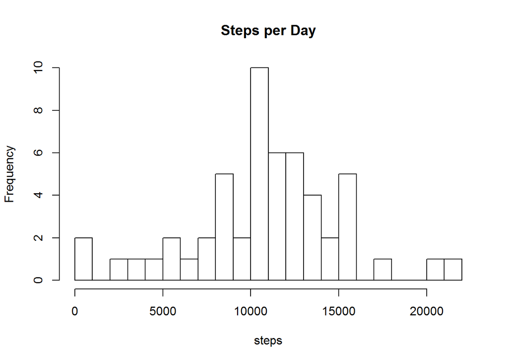

```r
StepsPerDay <- aggregate(steps~date, table, sum)
hist(StepsPerDay$steps, xlab="steps", main="Steps per Day", breaks=20)
```

```r
mean(StepsPerDay$steps)
```

```
## [1] 10766
```

```r
median(StepsPerDay$steps)
```

```
## [1] 10765
```

## 2) What is the average daily activity pattern?

Calculating the total mean of the steps within each 5-minute interval on all the days

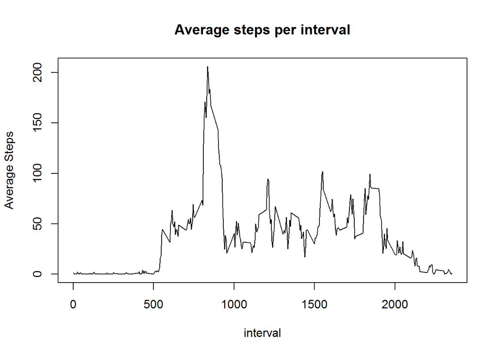

```r
intervals <- aggregate(steps~interval, table, mean)
colnames(intervals)[2] <- "mean_steps"
plot(intervals, type="l", ylab="Average Steps", main="Average steps per interval")
```

```r
max.interval <- intervals[intervals$mean.steps == max(intervals$mean.steps), 1]
intervals[intervals$interval == max.interval, ]
```

```
## [1] interval   mean_steps
## <0 rows> (or 0-length row.names)
```